# bambu

## Check expression estimates

We can check the estimated transcript expression using heatmap:

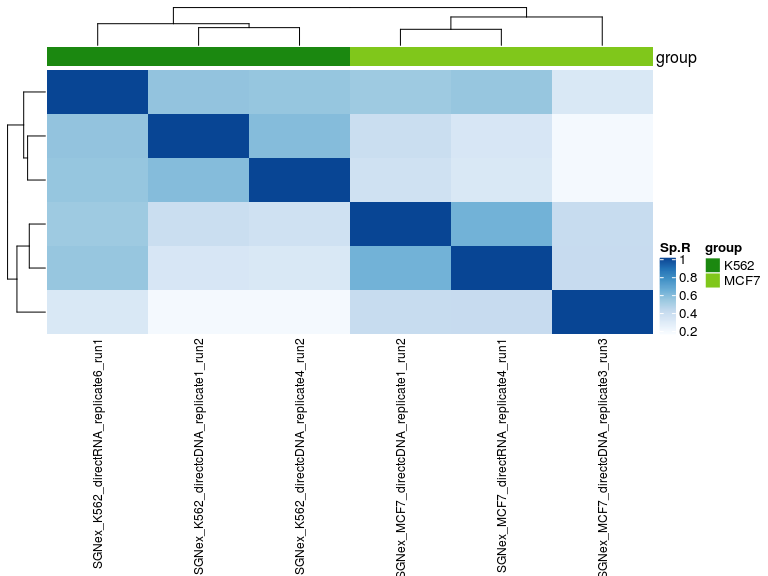

```r
colData(seExtended)$groupVar <-  unlist(lapply(colnames(seExtended),function(x) unlist(strsplit(x,"_"))[2]))
colnames(seExtended) <- gsub("_genome_chr22_1_25409234","",colnames(seExtended))
colData(seExtended)$name <- gsub("_genome_chr22_1_25409234","",colData(seExtended)$name)
plot.bambu(seExtended, group.variable = "groupVar", type = "heatmap")
```

or with PCA plot

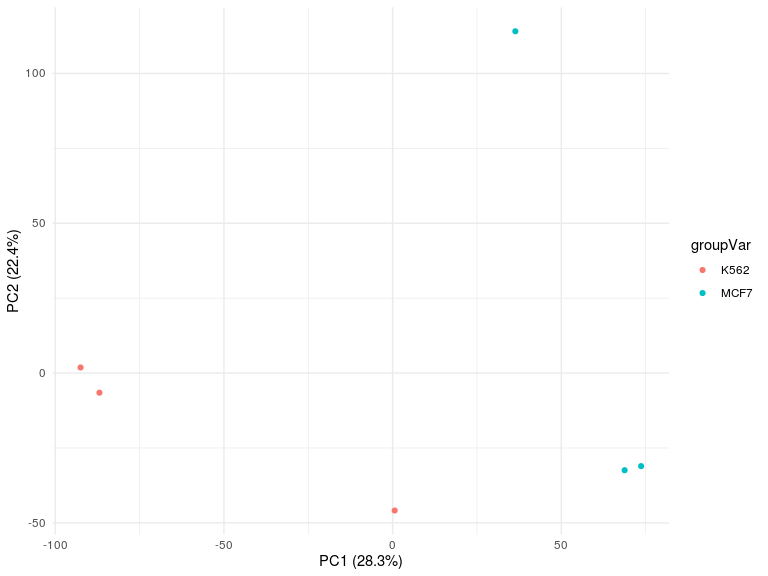

```r
colData(seExtended)$groupVar <-  unlist(lapply(colnames(seExtended),function(x) unlist(strsplit(x,"_"))[2]))
plot.bambu(seExtended, group.variable = "groupVar", type = "pca")
```

### Check for gene examples

Single gene examples can also be checked using plot functions from *bambu*

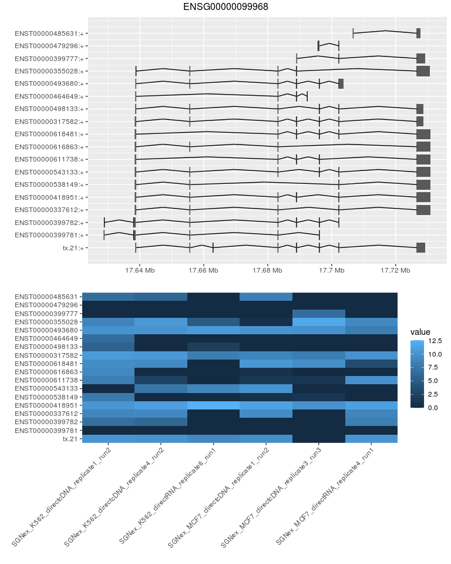

```
##> [[1]]
##> TableGrob (3 x 1) "arrange": 3 grobs
##>   z     cells    name                grob
##> 1 1 (2-2,1-1) arrange      gtable[layout]
##> 2 2 (3-3,1-1) arrange      gtable[layout]
##> 3 3 (1-1,1-1) arrange text[GRID.text.210]
```

```r
plot.bambu(seExtended, type = "annotation", gene_id = unique(rowData(seExtended)$GENEID)[10])
```

### Transcript to Gene expression

Gene expression can be obtained from transcript expression using this function:

```r
seGene <- transcriptToGeneExpression(seExtended)
seGene
##> class: RangedSummarizedExperiment
##> dim: 887 6
##> metadata(0):
##> assays(2): counts CPM
##> rownames(887): ENSG00000015475 ENSG00000040608 ... gene.98 gene.99
##> rowData names(2): GENEID newGeneClass
##> colnames(6): SGNex_K562_directcDNA_replicate1_run2
##>   SGNex_K562_directcDNA_replicate4_run2 ...
##>   SGNex_MCF7_directcDNA_replicate3_run3
##>   SGNex_MCF7_directRNA_replicate4_run1
##> colData names(2): name groupVar
```

Gene expression heatmap

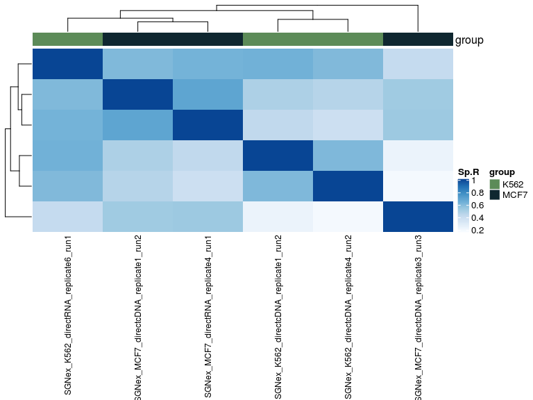

```r
colData(seGene)$groupVar <-  unlist(lapply(colnames(seGene),function(x) unlist(strsplit(x,"_"))[2]))
plot.bambu(seGene, group.variable = "groupVar", type = "heatmap")
```

Gene expression PCA plot

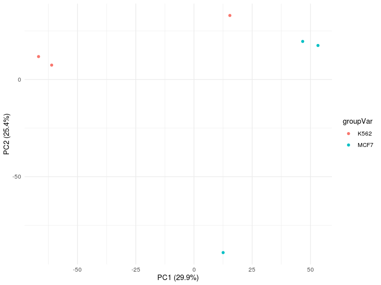

```r
colData(seGene)$groupVar <-  unlist(lapply(colnames(seGene),function(x) unlist(strsplit(x,"_"))[2]))
plot.bambu(seGene, group.variable = "groupVar", type = "pca")
```

## Differentially expressed genes

We used *DESeq2* to find the differentially expressed genes:

```r
library(DESeq2)
dds <- DESeqDataSetFromMatrix(apply(assays(seGene)$counts,c(1,2),round),#tmp_wide[,-1],
                                   colData = colData(seExtended),
                                   design = ~ groupVar)
system.time(dds.deseq <- DESeq(dds))
##>    user  system elapsed
##>   2.020   0.068   2.089

deGeneRes <- DESeq2::results(dds.deseq, independentFiltering=FALSE)
```

```r
head(deGeneRes[order(deGeneRes$padj),])
##> log2 fold change (MLE): groupVar MCF7 vs K562
##> Wald test p-value: groupVar MCF7 vs K562
##> DataFrame with 6 rows and 6 columns
##>                  baseMean log2FoldChange     lfcSE      stat
##>                 <numeric>      <numeric> <numeric> <numeric>
##> ENSG00000185686  513.5554       -7.22327  0.498140 -14.50048
##> ENSG00000197077   26.2357        9.09835  1.326114   6.86091
##> ENSG00000283633   88.7407       -9.03039  1.431724  -6.30736
##> ENSG00000099977  232.6720        1.85141  0.306629   6.03795
##> ENSG00000169635   44.4275       -3.44047  0.579080  -5.94127
##> ENSG00000100181   38.3698       -5.07047  0.892940  -5.67840
##>                                                                 pvalue
##>                                                              <numeric>
##> ENSG00000185686 0.0000000000000000000000000000000000000000000000120303
##> ENSG00000197077 0.0000000000068425448545783570607904382313656081217312
##> ENSG00000283633 0.0000000002838407468976333203669654163178986266968806
##> ENSG00000099977 0.0000000015607995974142258612474572408387353539271913
##> ENSG00000169635 0.0000000028282083250919303521398367383355917925591427
##> ENSG00000100181 0.0000000135958879211409468852046023923732520621854292
##>                                                                 padj
##>                                                            <numeric>
##> ENSG00000185686 0.00000000000000000000000000000000000000000000714599
##> ENSG00000197077 0.00000000203223582180977191457661517551974705853013
##> ENSG00000283633 0.00000005620046788573139474432216163360398475390411
##> ENSG00000099977 0.00000023177874021601254939083656177872816428475744
##> ENSG00000169635 0.00000033599114902092130879429198592189820260500710
##> ENSG00000100181 0.00000134599290419295367876952908281484866392929689
```

```r
summary(deGeneRes)
##>
##> out of 594 with nonzero total read count
##> adjusted p-value < 0.1
##> LFC > 0 (up)       : 16, 2.7%
##> LFC < 0 (down)     : 20, 3.4%
##> outliers [1]       : 0, 0%
##> low counts [2]     : 0, 0%
##> (mean count < 0)
##> [1] see 'cooksCutoff' argument of ?results
##> [2] see 'independentFiltering' argument of ?results
```

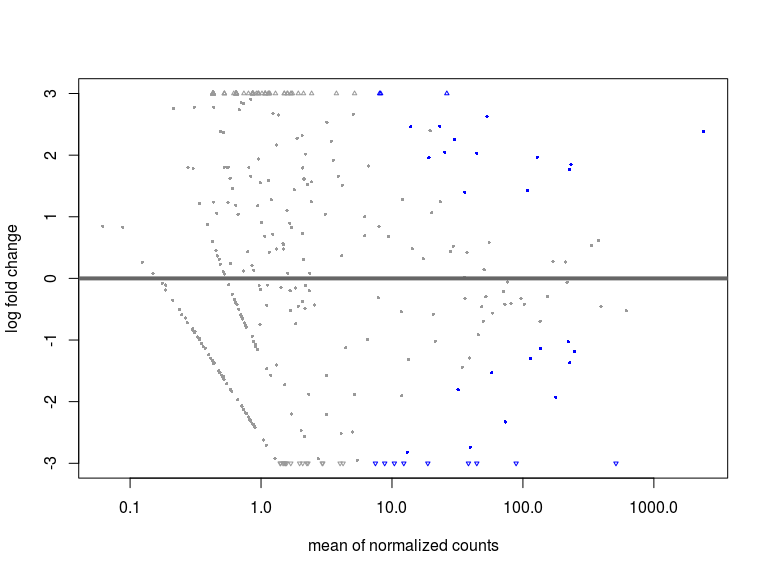

```r
plotMA(deGeneRes, ylim = c(-3,3))
```

Plotting shrinked lFC results

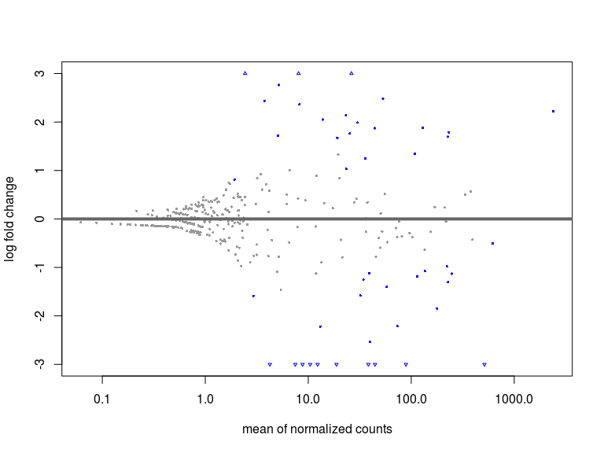

```r
resLFC <- lfcShrink(dds.deseq, coef="groupVar_MCF7_vs_K562", type="apeglm")
plotMA(resLFC, ylim = c(-3,3))
```

## Differential expression for isoform detection

We used *DEXSeq* to detect alternative used isoforms.

```r
library(DRIMSeq)
count.data <- as.data.frame(rowData(seExtended))
count.data$gene_id <- count.data$GENEID
count.data$feature_id <- count.data$TXNAME
count.data$GENEID <- count.data$TXNAME <- NULL

count.data <- cbind(count.data, assays(seExtended)$counts)

sample.info <- as.data.frame(colData(seExtended))
sample.info$sample_id <- sample.info$name
sample.info$name <- NULL
d <- dmDSdata(counts=count.data, samples=sample.info)

n_samp_gene <- 1
n_samp_feature <- 1
min_count_gene <- 1
min_count_feature <- 1
dFilter <- dmFilter(d,
              min_samps_feature_expr = n_samp_feature,
              min_samps_feature_prop = n_samp_feature,
              min_samps_gene_expr = n_samp_gene,
              min_feature_expr = min_count_feature,
              min_gene_expr = min_count_gene,
              min_feature_prop=0.1)
table(table(counts(dFilter)$gene_id)) ## number of isoforms
##>
##>  2  3  4  5  6  7  8 10
##> 23 15 21 12  8  6  4  1
```

```r
library(DEXSeq)
formulaFullModel <- as.formula("~sample + exon + groupVar:exon")


dxd <- DEXSeqDataSet(countData=round(as.matrix(counts(dFilter)[,-c(1:2)])),
                     sampleData=DRIMSeq::samples(dFilter),
                     design=formulaFullModel,
                     featureID = counts(dFilter)$feature_id,
                     groupID=counts(dFilter)$gene_id)


system.time({
  dxd <- estimateSizeFactors(dxd)
  print('Size factor estimated')
  dxd <- estimateDispersions(dxd, formula = formulaFullModel)
  print('Dispersion estimated')
  #dxd <- estimateExonFoldChanges( dxd )
  dxd <- testForDEU(dxd, fullModel = formulaFullModel)
  print('DEU tested')
  dxd <- estimateExonFoldChanges(dxd, fitExpToVar="groupVar")
  print('Exon fold changes estimated')
})
##> [1] "Size factor estimated"
##> [1] "Dispersion estimated"
##> [1] "DEU tested"
##> [1] "Exon fold changes estimated"
##>    user  system elapsed
##>   7.816   0.024   7.844
```

```r
dxr <- DEXSeqResults(dxd, independentFiltering=FALSE)
head(dxr)
##>
##> LRT p-value: full vs reduced
##>
##> DataFrame with 6 rows and 12 columns
##>                   groupID   featureID exonBaseMean dispersion      stat
##>               <character> <character>    <numeric>  <numeric> <numeric>
##> gene.2:tx.2        gene.2        tx.2     2.714822   0.427670  3.150551
##> gene.2:tx.3        gene.2        tx.3     0.654029   0.791030  0.140914
##> gene.2:tx.4        gene.2        tx.4     2.567833   0.315359  1.003001
##> gene.2:tx.66       gene.2       tx.66     2.107202   0.332461  0.422016
##> gene.2:tx.67       gene.2       tx.67     1.243100   1.748445  1.683733
##> gene.2:tx.122      gene.2      tx.122     1.865452   0.467004  1.043483
##>                  pvalue      padj      K562      MCF7 log2fold_MCF7_K562
##>               <numeric> <numeric> <numeric> <numeric>          <numeric>
##> gene.2:tx.2   0.0759013   0.99485   2.14944 0.0448427         -11.620740
##> gene.2:tx.3   0.7073738   1.00000   1.15465 0.0448419          -9.506951
##> gene.2:tx.4   0.3165853   1.00000   2.03209 1.1710398          -1.860342
##> gene.2:tx.66  0.5159328   1.00000   1.58048 1.8911532           0.622989
##> gene.2:tx.67  0.1944292   1.00000   1.05916 1.7073365           1.554900
##> gene.2:tx.122 0.3070128   1.00000   1.44728 1.8878239           0.910422
##>                 genomicData   countData
##>               <GRangesList>    <matrix>
##> gene.2:tx.2                 18:13:3:...
##> gene.2:tx.3                   2:3:2:...
##> gene.2:tx.4                 10:15:3:...
##> gene.2:tx.66                  7:5:3:...
##> gene.2:tx.67                  0:6:0:...
##> gene.2:tx.122                 2:9:1:...
```

```r
library(stageR)
strp <- function(x) substr(x,1,15)
qval <- perGeneQValue(dxr)
dxr.g <- data.frame(gene=names(qval),qval)

columns <- c("featureID","groupID","pvalue")
dxr_pval <- as.data.frame(dxr[,columns])
head(dxr_pval)
##>               featureID groupID     pvalue
##> gene.2:tx.2        tx.2  gene.2 0.07590133
##> gene.2:tx.3        tx.3  gene.2 0.70737384
##> gene.2:tx.4        tx.4  gene.2 0.31658535
##> gene.2:tx.66      tx.66  gene.2 0.51593283
##> gene.2:tx.67      tx.67  gene.2 0.19442922
##> gene.2:tx.122    tx.122  gene.2 0.30701285

pConfirmation <- matrix(dxr_pval$pvalue,ncol=1)
dimnames(pConfirmation) <- list(strp(dxr_pval$featureID),"transcript")
pScreen <- qval
names(pScreen) <- strp(names(pScreen))
tx2gene <- as.data.frame(dxr_pval[,c("featureID", "groupID")])
for (i in 1:2) tx2gene[,i] <- strp(tx2gene[,i])


stageRObj <- stageRTx(pScreen=pScreen, pConfirmation=pConfirmation,
                      pScreenAdjusted=TRUE, tx2gene=tx2gene)
stageRObj <- stageWiseAdjustment(stageRObj, method="dtu", alpha=0.5)
suppressWarnings({
  dex.padj <- getAdjustedPValues(stageRObj, order=FALSE,
                                 onlySignificantGenes=TRUE)
})
```

```r
dxrDT <- data.table(as.data.frame(dxr))
setnames(dxrDT, old = c('groupID','featureID'), new = c('geneID','txID'))
dex.padj <- data.table(dex.padj)

dxrDT <- dex.padj[dxrDT, on = c('geneID','txID')]
head(dxrDT)
##>    geneID   txID gene transcript exonBaseMean dispersion      stat     pvalue
##> 1: gene.2   tx.2   NA         NA    2.7148218  0.4276702 3.1505509 0.07590133
##> 2: gene.2   tx.3   NA         NA    0.6540286  0.7910296 0.1409142 0.70737384
##> 3: gene.2   tx.4   NA         NA    2.5678325  0.3153589 1.0030014 0.31658535
##> 4: gene.2  tx.66   NA         NA    2.1072015  0.3324607 0.4220160 0.51593283
##> 5: gene.2  tx.67   NA         NA    1.2431000  1.7484453 1.6837326 0.19442922
##> 6: gene.2 tx.122   NA         NA    1.8654524  0.4670041 1.0434828 0.30701285
##>         padj     K562       MCF7 log2fold_MCF7_K562 genomicData
##> 1: 0.9948496 2.149443 0.04484265        -11.6207395   <GRanges>
##> 2: 1.0000000 1.154654 0.04484192         -9.5069512   <GRanges>
##> 3: 1.0000000 2.032089 1.17103980         -1.8603417   <GRanges>
##> 4: 1.0000000 1.580476 1.89115320          0.6229887   <GRanges>
##> 5: 1.0000000 1.059156 1.70733655          1.5549004   <GRanges>
##> 6: 1.0000000 1.447282 1.88782389          0.9104218   <GRanges>
##>    countData.SGNex_K562_directcDNA_replicate1_run2
##> 1:                                              18
##> 2:                                               2
##> 3:                                              10
##> 4:                                               7
##> 5:                                               0
##> 6:                                               2
##>    countData.SGNex_K562_directcDNA_replicate4_run2
##> 1:                                              13
##> 2:                                               3
##> 3:                                              15
##> 4:                                               5
##> 5:                                               6
##> 6:                                               9
##>    countData.SGNex_K562_directRNA_replicate6_run1
##> 1:                                              3
##> 2:                                              2
##> 3:                                              3
##> 4:                                              3
##> 5:                                              0
##> 6:                                              1
##>    countData.SGNex_MCF7_directcDNA_replicate1_run2
##> 1:                                               0
##> 2:                                               0
##> 3:                                               0
##> 4:                                               1
##> 5:                                               1
##> 6:                                               1
##>    countData.SGNex_MCF7_directcDNA_replicate3_run3
##> 1:                                               0
##> 2:                                               0
##> 3:                                               1
##> 4:                                               2
##> 5:                                               0
##> 6:                                               2
##>    countData.SGNex_MCF7_directRNA_replicate4_run1
##> 1:                                              0
##> 2:                                              0
##> 3:                                              0
##> 4:                                              0
##> 5:                                              1
##> 6:                                              0
```

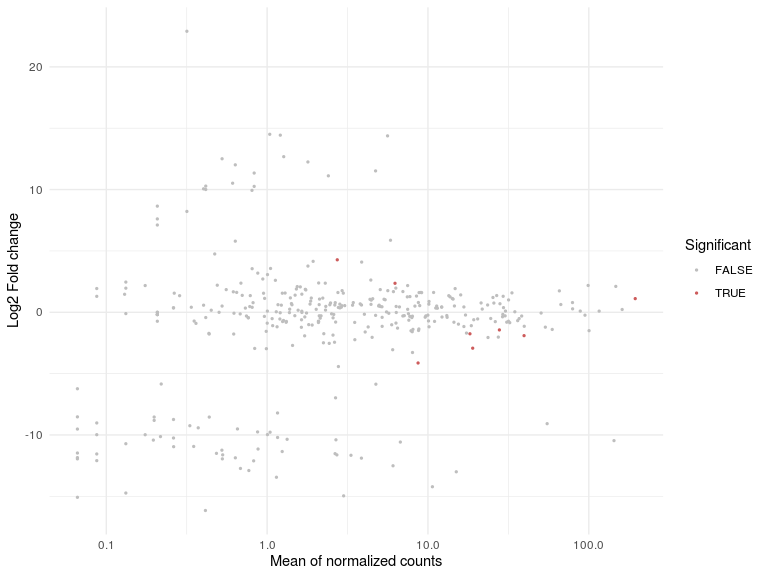

```r
dxrDT[,sigLFC2:=(padj < 0.5&(abs(log2fold_MCF7_K562)>=2))]
ggplot(dxrDT, aes(y = log2fold_MCF7_K562, x = exonBaseMean, color = as.factor(padj<0.5)))+
  geom_point(size = 0.5)+
     scale_x_log10()+
  scale_color_manual(values = c('grey','indianred'), name = "Significant")+
     xlab("Mean of normalized counts")+
    ylab("Log2 Fold change")+
  theme_minimal()
```

```r
dxrDT[padj<0.5,.(geneID, txID, log2fold_MCF7_K562,K562,MCF7)]
##>             geneID            txID log2fold_MCF7_K562      K562     MCF7
##> 1: ENSG00000183597           tx.35          -2.925745 4.2504114 2.284457
##> 2: ENSG00000184436           tx.44          -4.132398 3.3428343 1.103626
##> 3: ENSG00000272779          tx.105           4.276779 0.6241729 2.320295
##> 4: ENSG00000100030 ENST00000215832           1.112208 5.7031758 6.535581
##> 5: ENSG00000100030 ENST00000398822          -1.438071 4.0021766 3.004256
##> 6: ENSG00000169635 ENST00000407464           2.362562 1.9298346 3.404064
##> 7: ENSG00000169635 ENST00000443632          -1.904184 4.0971165 2.785404
##> 8: ENSG00000215012 ENST00000407472          -1.753270 3.6246114 2.462383
```